# Análisis del Marketing Mix y Optimización del Presupuesto Publicitario

Paula Zabaleta Eizaga

2025-05-18

# 1. Carga y exploración de datos

Antes de realizar cualquier análisis econométrico, es fundamental conocer el conjunto de datos con el que se va a trabajar. Este paso inicial permite detectar posibles errores, formatos incorrectos, valores faltantes o inconsistencias. Se cargan los datos desde un archivo Excel, y a través de funciones como head(), str() y summary() se obtiene una primera visión del tipo de variables disponibles, su estructura y distribución general. Este reconocimiento preliminar es imprescindible para asegurar una correcta manipulación posterior y una selección adecuada de variables.

```r
library(readxl)
df <- read_excel("C:/Users/Pzabaletaeizaga/OneDrive/Documentos/cuarto carrera/TRABAJO DE FIN DE GRADO/dataset.xlsx")
head(df)
```

```
## # A tibble: 6 × 113
##   Fecha                `A` ud_venta_fisica Week1 Week2 Week3 Week4 Week5   IPC
##   <dttm>              <dbl>           <dbl> <dbl> <dbl> <dbl> <dbl> <dbl> <dbl>
## 1 2021-01-10 00:00:00  2021         195532.     1     0     0     0     0  105.
## 2 2021-01-17 00:00:00  2021          91390.     0     1     0     0     0  105.
## 3 2021-01-24 00:00:00  2021          77548.     0     0     1     0     0  105.
## 4 2021-01-31 00:00:00  2021          69549      0     0     0     1     0  105.
## 5 2021-02-07 00:00:00  2021          57358.     1     0     0     0     0  104.
## 6 2021-02-14 00:00:00  2021          56970      0     1     0     0     0  104.
## # ℹ 104 more variables: tasa_paro <dbl>, muertes_covid <dbl>, tmed <dbl>,
## #   TOTAL_TMED_P <dbl>, prec <dbl>, Dias_pagos <dbl>, Navidad <dbl>,
## #   Ano_Nuevo <dbl>, Reyes <dbl>, Pre_Navidad <dbl>, Semana_Santa <dbl>,
## #   Agosto_15 <dbl>, Puente_Diciembre <dbl>, `D?_Madre` <dbl>, Santos <dbl>,
## #   October12 <dbl>, mayio15 <dbl>, November9 <dbl>, San_Valentin <dbl>,
## #   PRE_BLACK_FRIDAY <dbl>, BLACK_FRIDAY <dbl>, Month <dbl>, Jan <dbl>,
## #   Feb <dbl>, Mar <dbl>, Apr <dbl>, May <dbl>, Jun <dbl>, Jul <dbl>, …
```

```r
str(df)
```

```
## tibble [116 × 113] (S3: tbl_df/tbl/data.frame)
##  $ Fecha                                    : POSIXct[1:116], format: "2021-01-10" "2021-01-17" ...
##  $ A                                       : num [1:116] 2021 2021 2021 2021 2021 ...
##  $ ud_venta_fisica                          : num [1:116] 195533 91391 77549 69549 57359 ...
##  $ Week1                                    : num [1:116] 1 0 0 0 1 0 0 0 1 0 ...
##  $ Week2                                    : num [1:116] 0 1 0 0 0 1 0 0 0 1 ...
##  $ Week3                                    : num [1:116] 0 0 1 0 0 0 1 0 0 0 ...
##  $ Week4                                    : num [1:116] 0 0 0 1 0 0 0 1 0 0 ...
##  $ Week5                                    : num [1:116] 0 0 0 0 0 0 0 0 0 0 ...
##  $ IPC                                      : num [1:116] 105 105 105 105 104 ...
##  $ tasa_paro                                : num [1:116] 16 16 16 16 16 ...
##  $ muertes_covid                            : num [1:116] 1037 1440 2127 1871 3067 ...
##  $ tmed                                     : num [1:116] 2.92 4.34 8.83 12.66 11.65 ...
##  $ TOTAL_TMED_P                             : num [1:116] 3.32 3.68 7.25 10.54 9.98 ...
##  $ prec                                     : num [1:116] 4.85 0.12 2.82 1.49 2.74 2.39 1.67 0.77 1.22 0.47 ...
```

[output cut: 86 more lines]

```r
summary(df)
```

```
##      Fecha                           A       ud_venta_fisica      Week1
##  Min.   :2021-01-10 00:00:00   Min.   :2021   Min.   : 34779   Min.   :0.0000
##  1st Qu.:2021-07-30 06:00:00   1st Qu.:2021   1st Qu.: 46670   1st Qu.:0.0000
##  Median :2022-02-16 12:00:00   Median :2022   Median : 59764   Median :0.0000
##  Mean   :2022-02-16 12:00:00   Mean   :2022   Mean   : 78627   Mean   :0.2328
##  3rd Qu.:2022-09-05 18:00:00   3rd Qu.:2022   3rd Qu.: 96279   3rd Qu.:0.0000
##  Max.   :2023-03-26 00:00:00   Max.   :2023   Max.   :283356   Max.   :1.0000
##      Week2            Week3            Week4            Week5
##  Min.   :0.0000   Min.   :0.0000   Min.   :0.0000   Min.   :0.00000
##  1st Qu.:0.0000   1st Qu.:0.0000   1st Qu.:0.0000   1st Qu.:0.00000
##  Median :0.0000   Median :0.0000   Median :0.0000   Median :0.00000
##  Mean   :0.2328   Mean   :0.2328   Mean   :0.2328   Mean   :0.06897
##  3rd Qu.:0.0000   3rd Qu.:0.0000   3rd Qu.:0.0000   3rd Qu.:0.00000
##  Max.   :1.0000   Max.   :1.0000   Max.   :1.0000   Max.   :1.00000
##       IPC           tasa_paro     muertes_covid         tmed
##  Min.   : 99.29   Min.   :12.48   Min.   :  92.0   Min.   : 2.92
##  1st Qu.:102.74   1st Qu.:12.87   1st Qu.: 312.0   1st Qu.:10.71
##  Median :106.31   Median :13.33   Median : 312.0   Median :13.70
##  Mean   :105.86   Mean   :13.78   Mean   : 585.1   Mean   :15.08
##  3rd Qu.:109.70   3rd Qu.:14.57   3rd Qu.: 613.8   3rd Qu.:19.54
##  Max.   :110.70   Max.   :15.98   Max.   :3361.0   Max.   :27.04
##   TOTAL_TMED_P         prec         Dias_pagos       Navidad
##  Min.   : 3.320   Min.   :0.000   Min.   : 1.00   Min.   :0.00000
##  1st Qu.: 9.115   1st Qu.:0.470   1st Qu.: 8.00   1st Qu.:0.00000
##  Median :11.700   Median :1.180   Median :16.00   Median :0.00000
##  Mean   :12.626   Mean   :1.418   Mean   :16.05   Mean   :0.01724
##  3rd Qu.:16.185   3rd Qu.:1.940   3rd Qu.:23.25   3rd Qu.:0.00000
##  Max.   :22.190   Max.   :4.850   Max.   :31.00   Max.   :1.00000
##    Ano_Nuevo           Reyes          Pre_Navidad       Semana_Santa
##  Min.   :0.00000   Min.   :0.00000   Min.   :0.00000   Min.   :0.00000
##  1st Qu.:0.00000   1st Qu.:0.00000   1st Qu.:0.00000   1st Qu.:0.00000
##  Median :0.00000   Median :0.00000   Median :0.00000   Median :0.00000
##  Mean   :0.01724   Mean   :0.02586   Mean   :0.01724   Mean   :0.01724
##  3rd Qu.:0.00000   3rd Qu.:0.00000   3rd Qu.:0.00000   3rd Qu.:0.00000
##  Max.   :1.00000   Max.   :1.00000   Max.   :1.00000   Max.   :1.00000
##    Agosto_15        Puente_Diciembre     D?_Madre           Santos
##  Min.   :0.000000   Min.   :0.00000   Min.   :0.00000   Min.   :0.000000
##  1st Qu.:0.000000   1st Qu.:0.00000   1st Qu.:0.00000   1st Qu.:0.000000
##  Median :0.000000   Median :0.00000   Median :0.00000   Median :0.000000
##  Mean   :0.008621   Mean   :0.01724   Mean   :0.01724   Mean   :0.008621
```

[output cut: 197 more lines]

```
##  Max.   :36323038      Max.   :39176631      Max.   :27318718
##  impresiones_meta_2021_edit indice_dto_medio_fisica_2     PRE_BF
##  Min.   :       0           Min.   :0.0000            Min.   :0.0000
##  1st Qu.:       0           1st Qu.:0.0000            1st Qu.:0.0000
##  Median :       0           Median :0.0000            Median :0.0000
##  Mean   : 8143821           Mean   :0.9166            Mean   :0.0431
##  3rd Qu.:18047800           3rd Qu.:1.9013            3rd Qu.:0.0000
##  Max.   :36323038           Max.   :2.1705            Max.   :1.0000
##   ANO_NUEVO_BF     NAVIDAD_DIAMADRE  indice_dto_medio_fisica_3
##  Min.   :0.00000   Min.   :0.00000   Min.   :0.0000
##  1st Qu.:0.00000   1st Qu.:0.00000   1st Qu.:0.0000
##  Median :0.00000   Median :0.00000   Median :0.0000
##  Mean   :0.03448   Mean   :0.03448   Mean   :0.8782
##  3rd Qu.:0.00000   3rd Qu.:0.00000   3rd Qu.:1.8471
##  Max.   :1.00000   Max.   :1.00000   Max.   :2.2616
```

# 2. Selección de variables clave

Para la construcción del modelo se ha seleccionado un conjunto de variables explicativas que recogen las principales palancas del marketing mix, así como factores externos relevantes. En primer lugar, se incluye la variable impresiones como medida de la presión publicitaria online, al tratarse de una variable continua que refleja la visibilidad de la marca en medios digitales y está disponible de forma consistente a lo largo del periodo analizado. En segundo lugar, se incorpora el indice_dto_medio_fisica_2 como aproximación al nivel de descuento medio aplicado en tienda física, siendo una variable clave para capturar el efecto de las promociones sobre las ventas. Para controlar por eventos comerciales que generan fuertes fluctuaciones en el comportamiento del consumidor, se han incluido variables binarias como PRE_BF, NAVIDAD_DIAMADRE y ANO_NUEVO_BF, que identifican semanas asociadas a campañas específicas. Por otro lado, tambíen se introducen las variebles notoriedad y precipitaciones, la notoriedad recoge el efecto acumulado de la marca en la mente del consumidor y las precipitaciones actúan como factor externo que puede influir en el tráfico a tienda. Por último, se incorporan las variables IPC y tasa_paro, que permiten recoger el contexto macroeconómico general y evitar que el modelo atribuya a acciones de marketing efectos derivados de la evolución de precios o del mercado laboral. Todas estas variables han sido seleccionadas por su relevancia teórica, su disponibilidad en el dataset y su capacidad de capturar distintos factores que afectan al comportamiento de compra en tienda física.

```r
#Se crea un dataframe con las variables seleccionadas
modelo_1 <- df[, c("ud_venta_fisica",
                        "impresiones_meta",
                        "indice_dto_medio_fisica_2",
                        "PRE_BF",
                        "NAVIDAD_DIAMADRE",
                        "ANO_NUEVO_BF",
                        "IPC",
                        "tasa_paro",
                        "prec",
                        "notoriedad")]
head(modelo_1)
```

```
## # A tibble: 6 × 10
##   ud_venta_fisica impresiones_meta indice_dto_medio_fisica_2 PRE_BF
##             <dbl>            <dbl>                     <dbl>  <dbl>
## 1         195532.        29547243                       1.48      0
## 2          91390.        24949342.                      1.83      0
## 3          77548.        24545271                       2.05      0
## 4          69549         27454076.                      2.13      0
## 5          57358.        24420134.                      2.07      0
## 6          56970         22771318.                      1.97      0
## # ℹ 6 more variables: NAVIDAD_DIAMADRE <dbl>, ANO_NUEVO_BF <dbl>, IPC <dbl>,
## #   tasa_paro <dbl>, prec <dbl>, notoriedad <dbl>
```

# 3. Transformaciones: log, adstock, saturación

La aplicación de transformaciones permite mejorar la interpretación económica de los coeficientes y ajustar el modelo a comportamientos no lineales propios del marketing. El logaritmo natural se aplica para transformar tanto la variable dependiente como algunas independientes, permitiendo interpretar los coeficientes como elasticidades. La transformación de Adstock se utiliza para reflejar el efecto acumulado y retardado de la publicidad: no solo impacta en la semana actual, sino también en las siguientes, aunque con menor intensidad. Finalmente, se aplica una saturación logarítmica sobre la variable de Adstock, lo que permite reflejar rendimientos decrecientes: a partir de cierto nivel, más publicidad no necesariamente implica más ventas.

```r
# Se crean nuevas columnas con los logaritmos
modelo_1$log_ventas <- log(modelo_1$ud_venta_fisica)
modelo_1$log_impresiones <- log(modelo_1$impresiones_meta + 1)
modelo_1$log_descuento <- log(modelo_1$indice_dto_medio_fisica_2 + 1)

# También transformamos notoriedad si tiene ceros o es muy sesgada
modelo_1$log_notoriedad <- log(modelo_1$notoriedad + 1)

# Revisamos si prec tiene valores negativos (no debería), y transformamos si es necesario
modelo_1$log_prec <- log(modelo_1$prec + 1)

# Comprobamos que están creadas correctamente
head(modelo_1[, c("log_ventas", "log_impresiones", "log_descuento", "log_prec", "log_notoriedad")])
```

```
## # A tibble: 6 × 5
##   log_ventas log_impresiones log_descuento log_prec log_notoriedad
##        <dbl>           <dbl>         <dbl>    <dbl>          <dbl>
## 1       12.2            17.2         0.906    1.77            4.32
## 2       11.4            17.0         1.04     0.113           4.16
## 3       11.3            17.0         1.12     1.34            4.08
## 4       11.1            17.1         1.14     0.912           4.00
## 5       11.0            17.0         1.12     1.32            3.91
## 6       11.0            16.9         1.09     1.22            3.82
```

```r
# Aplicamos el Adstock
adstock_transform <- function(x, lambda) {
  result <- numeric(length(x))
  result[1] <- x[1]
  for (t in 2:length(x)) {
    result[t] <- x[t] + lambda * result[t - 1]
  }
  return(result)
}

# Se aplica el Adstock a la variable de impresiones online con lambda = 0.5
modelo_1$adstock_impresiones <- adstock_transform(modelo_1$impresiones_meta, lambda = 0.5)

# Se comprueba que las dummies están bien escritas y no hay valores raros
unique(modelo_1$PRE_BF)
```

```
## [1] 0.0 0.5 1.0
```

```r
unique(modelo_1$NAVIDAD_DIAMADRE)
```

```
## [1] 0 1
```

```r
unique(modelo_1$ANO_NUEVO_BF)
```

```
## [1] 0 1
```

```r
colSums(is.na(modelo_1[, c("PRE_BF", "NAVIDAD_DIAMADRE", "ANO_NUEVO_BF")]))
```

```
##           PRE_BF NAVIDAD_DIAMADRE     ANO_NUEVO_BF
##                0                0                0
```

```r
modelo_1$PRE_BF[modelo_1$PRE_BF == 0.5] <- 1
unique(modelo_1$PRE_BF)
```

```
## [1] 0 1
```

# 4. Ajuste del modelo MMM

En este bloque se estima un modelo de regresión lineal múltiple. La variable dependiente es el logaritmo de las ventas físicas semanales. Las variables explicativas recogen diferentes dimensiones del marketing mix: descuentos, presión publicitaria, campañas estacionales, contexto macroeconómico y notoriedad de la marca. Este modelo tiene como objetivo principal cuantificar el impacto marginal de cada variable sobre las ventas. Los coeficientes estimados permiten identificar qué palancas tienen un mayor efecto sobre la demanda física, ayudando a fundamentar decisiones estratégicas y presupuestarias.

```r
# Aplicar saturación logarítmica al Adstock
modelo_1$sat_adstock_impresiones <- log(modelo_1$adstock_impresiones + 1)

# Ajustar el modelo con la variable saturada y las nuevas variables
modelo_mmm_1 <- lm(log_ventas ~ log_descuento + sat_adstock_impresiones +
                     log_prec + log_notoriedad +
                     PRE_BF + NAVIDAD_DIAMADRE + ANO_NUEVO_BF +
                     IPC + tasa_paro,
                   data = modelo_1)

# Ver el resumen del nuevo modelo
summary(modelo_mmm_1)
```

```
##
## Call:
## lm(formula = log_ventas ~ log_descuento + sat_adstock_impresiones +
##     log_prec + log_notoriedad + PRE_BF + NAVIDAD_DIAMADRE + ANO_NUEVO_BF +
##     IPC + tasa_paro, data = modelo_1)
##
## Residuals:
##      Min       1Q   Median       3Q      Max
## -0.42570 -0.17825 -0.04981  0.15373  1.14526
##
## Coefficients:
##                          Estimate Std. Error t value Pr(>|t|)
## (Intercept)              8.316482   1.420801   5.853 5.45e-08 ***
## log_descuento            0.331141   0.055050   6.015 2.60e-08 ***
## sat_adstock_impresiones  0.183355   0.072107   2.543 0.012441 *
## log_prec                -0.065645   0.057733  -1.137 0.258084
## log_notoriedad           0.879076   0.113991   7.712 7.12e-12 ***
## PRE_BF                  -0.673472   0.121037  -5.564 2.00e-07 ***
## NAVIDAD_DIAMADRE         0.347736   0.139822   2.487 0.014442 *
## ANO_NUEVO_BF             0.288911   0.149207   1.936 0.055491 .
## IPC                     -0.022273   0.007882  -2.826 0.005641 **
## tasa_paro               -0.104379   0.028661  -3.642 0.000421 ***
## ---
## Signif. codes:  0 '***' 0.001 '**' 0.01 '*' 0.05 '.' 0.1 ' ' 1
##
## Residual standard error: 0.2586 on 106 degrees of freedom
## Multiple R-squared:  0.7302, Adjusted R-squared:  0.7072
## F-statistic: 31.87 on 9 and 106 DF,  p-value: < 2.2e-16
```

Obtenemos un R^2 ajustado de 7072 lo que nos dice que el modelo explica casi un 71% de la variabilidad de las unidades de ventas físicas.

# 5. Diagnóstico del modelo

Una vez estimado el modelo, es esencial comprobar si se cumplen los supuestos clásicos de la regresión lineal: normalidad de los residuos, homocedasticidad (varianza constante), linealidad y ausencia de multicolinealidad. Para ello, se utilizan diferentes técnicas: análisis gráfico de los residuos (vs. valores ajustados, histograma, QQ-plot), tests estadísticos como el de Shapiro-Wilk para normalidad y Breusch-Pagan para heterocedasticidad, y el cálculo de VIF (Variance Inflation Factor) para evaluar correlaciones entre variables explicativas. Este diagnóstico permite validar la estabilidad del modelo y su idoneidad para realizar inferencias.

```r
# 1. Test de normalidad de Shapiro-Wilk
shapiro.test(residuals(modelo_mmm_1))
```

```
##
##  Shapiro-Wilk normality test
##
## data:  residuals(modelo_mmm_1)
## W = 0.91666, p-value = 2.197e-06
```

El test de normalidad de Shapiro-Wilk realizado sobre los residuos del modelo arroja un valor de W=0.91666 y un p-valor de 2.2×10−6, lo que indica que los residuos no siguen una distribución normal de forma estricta. Este resultado sugiere que existe cierta desviación respecto a la forma ideal de campana, aunque esto no invalida el modelo ni compromete su utilidad práctica.

En modelos aplicados al entorno del marketing, es habitual que los residuos no sean perfectamente normales debido a la naturaleza heterogénea y ruidosa de los datos. Además, la normalidad no es un requisito imprescindible para la validez del modelo de regresión múltiple, especialmente si el objetivo principal es explicativo o predictivo. Lo importante es que el modelo presente un buen ajuste, que los coeficientes sean estables y que las conclusiones sean útiles desde un punto de vista operativo, condiciones que en este caso sí se cumplen.

```r
residuos <- residuals(modelo_mmm_1)
ajustados <- fitted(modelo_mmm_1)
```

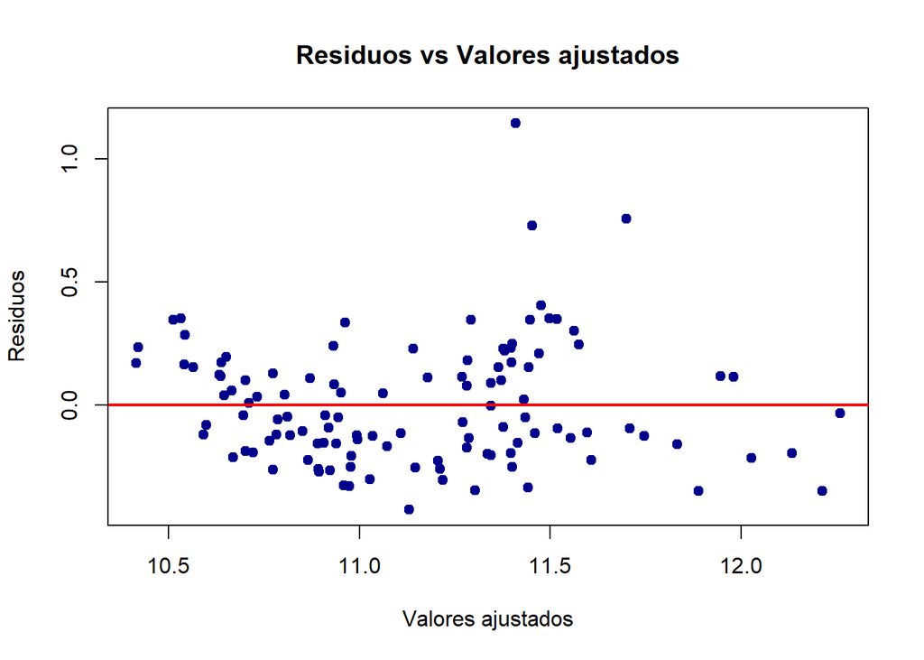

```r
# 3. Gráfico de residuos vs valores ajustados
plot(ajustados, residuos,
     main = "Residuos vs Valores ajustados",
     xlab = "Valores ajustados",
     ylab = "Residuos",
     pch = 19, col = "darkblue")
abline(h = 0, col = "red", lwd = 2)
```

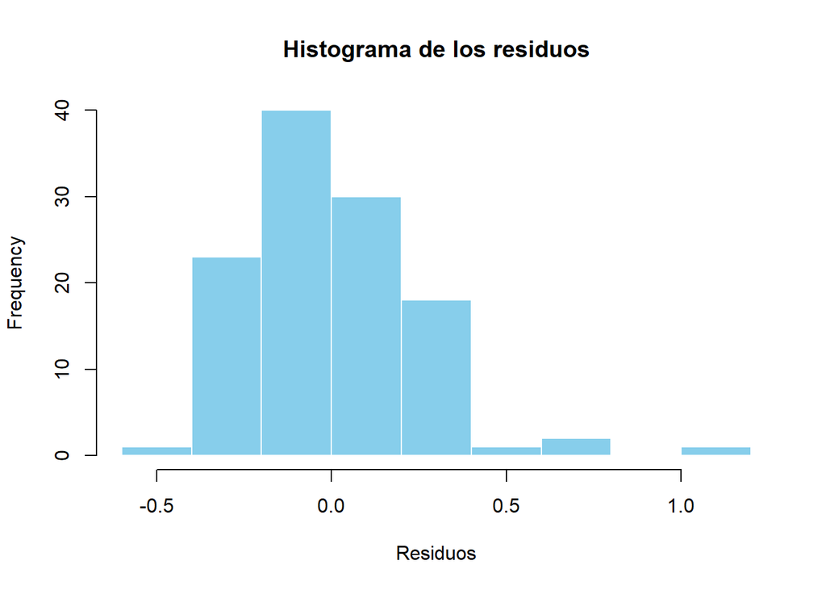

```r
# 4. Histograma de los residuos
hist(residuos,
     main = "Histograma de los residuos",
     xlab = "Residuos",
     col = "skyblue", border = "white")
```

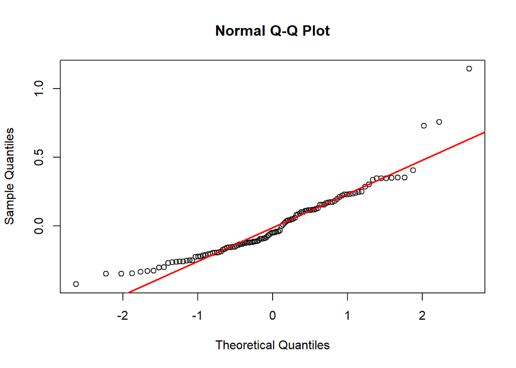

```r
# 5. QQ-plot para ver normalidad de los residuos
qqnorm(residuos, main = "Normal Q-Q Plot")
qqline(residuos, col = "red", lwd = 2)
```

```r
# 6. Test de Breusch-Pagan para heterocedasticidad
library(lmtest)
bptest(modelo_mmm_1)
```

```
##
##  studentized Breusch-Pagan test
##
## data:  modelo_mmm_1
## BP = 16.911, df = 9, p-value = 0.05013
```

```r
# 7. Multicolinealidad con VIF
library(car)
vif(modelo_mmm_1)
```

```
##           log_descuento sat_adstock_impresiones                log_prec
##                1.461338                1.992379                1.235991
##          log_notoriedad                  PRE_BF        NAVIDAD_DIAMADRE
##                1.942146                1.246708                1.129301
##            ANO_NUEVO_BF                     IPC               tasa_paro
##                1.285986                1.498527                1.844689
```

El histograma de los residuos presenta una distribución asimétrica hacia la derecha, aunque mayoritariamente centrada en torno a cero. Esta percepción se refuerza con el gráfico Q-Q, donde la mayoría de los puntos se alinean correctamente con la línea teórica, salvo en las colas, donde se observan pequeñas desviaciones. Esto indica que los residuos no siguen una distribución normal perfecta, lo cual queda confirmado por el test de Shapiro-Wilk, que arroja un p-valor muy bajo (𝑝≈2.2×10−6), lo que lleva a rechazar la hipótesis de normalidad. A pesar de ello, este resultado no invalida el modelo, ya que la regresión lineal es robusta ante desviaciones moderadas de normalidad, especialmente en contextos aplicados donde el objetivo es más explicativo o predictivo que inferencial.

Por otro lado, el test de Breusch-Pagan para evaluar la homocedasticidad arroja un p-valor de 0.05013, justo en el límite del umbral de significación. Aunque técnicamente no se puede rechazar la hipótesis nula de varianza constante, el resultado sugiere una posible presencia leve de heterocedasticidad, que convendría tener en cuenta si se fueran a utilizar los errores estándar para inferencias detalladas.

Finalmente, los factores de inflación de la varianza (VIF) se sitúan todos por debajo de 2, lo cual confirma la ausencia de multicolinealidad significativa entre las variables explicativas. Esto indica que los coeficientes estimados son estables y que las variables incluidas aportan información diferenciada al modelo.

En conclusión, aunque no se cumplen todos los supuestos clásicos de manera estricta, el modelo puede considerarse estadísticamente válido. Las desviaciones observadas son habituales en análisis de marketing con datos reales y no comprometen la interpretación ni la utilidad del modelo, especialmente cuando se busca evaluar tendencias generales y orientar decisiones estratégicas.

Como paso adicional, se va a realizar un diagnóstico robusto para darle una validación adicional al modelo.

```r
# Cargar el paquete necesario
library(MASS)

# Ajustar modelo robusto
modelo_mmm_1_robusto <- rlm(log_ventas ~ log_descuento + sat_adstock_impresiones +
                               log_prec + log_notoriedad +
                               PRE_BF + NAVIDAD_DIAMADRE + ANO_NUEVO_BF +
                               IPC + tasa_paro,
                             data = modelo_1)

# Ver resumen del modelo robusto
summary(modelo_mmm_1_robusto)
```

```
##
## Call: rlm(formula = log_ventas ~ log_descuento + sat_adstock_impresiones +
##     log_prec + log_notoriedad + PRE_BF + NAVIDAD_DIAMADRE + ANO_NUEVO_BF +
##     IPC + tasa_paro, data = modelo_1)
## Residuals:
##      Min       1Q   Median       3Q      Max
## -0.42459 -0.14453 -0.01641  0.14669  1.28498
##
## Coefficients:
##                         Value   Std. Error t value
## (Intercept)              9.8208  1.2563     7.8172
## log_descuento            0.3799  0.0487     7.8049
## sat_adstock_impresiones  0.1420  0.0638     2.2276
## log_prec                -0.0693  0.0510    -1.3577
## log_notoriedad           0.7521  0.1008     7.4622
## PRE_BF                  -0.5834  0.1070    -5.4512
## NAVIDAD_DIAMADRE         0.4492  0.1236     3.6337
## ANO_NUEVO_BF             0.4037  0.1319     3.0602
## IPC                     -0.0243  0.0070    -3.4894
## tasa_paro               -0.1151  0.0253    -4.5399
##
## Residual standard error: 0.2143 on 106 degrees of freedom
```

```r
# Crear tabla comparativa
comparacion_coef <- data.frame(
  Variable = names(coef(modelo_mmm_1)),
  Modelo_Lineal = round(coef(modelo_mmm_1), 4),
  Modelo_Robusto = round(coef(modelo_mmm_1_robusto), 4)
)

# Mostrar tabla
print(comparacion_coef)
```

```
##                                        Variable Modelo_Lineal Modelo_Robusto
## (Intercept)                         (Intercept)        8.3165         9.8208
## log_descuento                     log_descuento        0.3311         0.3799
## sat_adstock_impresiones sat_adstock_impresiones        0.1834         0.1420
## log_prec                               log_prec       -0.0656        -0.0693
## log_notoriedad                   log_notoriedad        0.8791         0.7521
## PRE_BF                                   PRE_BF       -0.6735        -0.5834
## NAVIDAD_DIAMADRE               NAVIDAD_DIAMADRE        0.3477         0.4492
## ANO_NUEVO_BF                       ANO_NUEVO_BF        0.2889         0.4037
## IPC                                         IPC       -0.0223        -0.0243
## tasa_paro                             tasa_paro       -0.1044        -0.1151
```

Con el objetivo de comprobar la estabilidad de los resultados y aumentar la fiabilidad del análisis, se estimó una versión robusta del modelo utilizando la función rlm, que permite mitigar la influencia de posibles valores atípicos y desviaciones respecto a la normalidad de los residuos. Al comparar los coeficientes obtenidos en el modelo lineal clásico y en el modelo robusto, se observa una consistencia general elevada en la dirección, magnitud e interpretación de los efectos.

Estas pequeñas diferencias son esperables en contextos con datos reales y no alteran las conclusiones fundamentales del análisis. En conjunto, este ejercicio confirma que las estimaciones obtenidas son estables y no están distorsionadas por la presencia de observaciones extremas, lo que refuerza la solidez del modelo como herramienta de análisis y simulación.

# 6. Estimación del ROI publicitario

El retorno sobre la inversión (ROI) es una métrica clave en marketing. Aquí se calcula el ROI estimado de la publicidad online utilizando el coeficiente del modelo asociado a las impresiones (tras aplicar Adstock y saturación). Este coeficiente se interpreta como el impacto promedio de la inversión en Meta Ads sobre las ventas físicas. Multiplicando ese efecto por la inversión media, se obtiene una estimación del valor generado en ventas físicas. Comparar ese valor con la inversión realizada permite calcular el ROI y valorar si el canal digital es rentable desde el punto de vista económico.

```r
# Coeficiente de la variable de publicidad digital (adstock saturado)
coef_adstock <- coef(modelo_mmm_1)["sat_adstock_impresiones"]

# Valor medio del adstock transformado
media_adstock <- mean(modelo_1$sat_adstock_impresiones, na.rm = TRUE)

# Impacto medio sobre el log de las ventas
impacto_logventas <- coef_adstock * media_adstock

# Media de ventas físicas semanales
media_ventas <- mean(modelo_1$ud_venta_fisica, na.rm = TRUE)

# Incremento estimado en ventas físicas por el canal publicitario
incremento_ventas <- media_ventas * impacto_logventas

# Media de inversión publicitaria en Meta Ads
media_inversion_meta <- mean(df$spent_meta, na.rm = TRUE)

# ROI estimado: retorno en ventas físicas / inversión media
roi_meta <- incremento_ventas / media_inversion_meta
roi_meta
```

```
## sat_adstock_impresiones
##                10.07092
```

Se obtiene un ROI estimado de 10.07, lo que implica que la inversión en publicidad digital a través de Meta Ads estaría generando un retorno elevado: por cada euro invertido, se estiman más de 10 euros en ventas físicas. Este resultado refleja una alta rentabilidad de las campañas durante el periodo analizado y respalda la utilidad del modelo como herramienta de evaluación del impacto publicitario. Dado que el modelo ha sido validado estadísticamente y no presenta problemas graves de diagnóstico, no se considera necesario recalcular el ROI mediante especificaciones alternativas. Las estimaciones son coherentes, estables y suficientes para sustentar conclusiones y recomendaciones prácticas.

# 7. Evaluación del impacto de variaciones en la inversión publicitaria

Este bloque introduce una técnica de simulación contrafactual: modificar el nivel de inversión publicitaria (aumentándolo o reduciéndolo un 10%) y observar cómo cambia el resultado esperado de ventas. Es un análisis “what if” que permite anticipar el comportamiento del mercado ante distintos niveles de presión publicitaria, manteniendo constantes las demás variables. Esta herramienta es útil para evaluar riesgos, oportunidades y planificar futuras campañas con mayor fundamento empírico.

**Evaluación del impacto de un aumento del 10% en la inversión publicitaria**

```r
# 1. Crear una copia del dataset original
df_sim <- modelo_1

# 2. Aumentar un 10% la variable sat_adstock_impresiones
df_sim$sat_adstock_impresiones <- df_sim$sat_adstock_impresiones * 1.10

# 3. Predecir las ventas logarítmicas usando el modelo final (modelo_mmm_1)
df_sim$log_ventas_simuladas <- predict(modelo_mmm_1, newdata = df_sim)

# 4. Transformar las predicciones a escala original
df_sim$ventas_simuladas <- exp(df_sim$log_ventas_simuladas)

# 5. Calcular el cambio porcentual medio en ventas
ventas_reales_media <- mean(modelo_1$ud_venta_fisica)
ventas_simuladas_media <- mean(df_sim$ventas_simuladas)

incremento_pct <- ((ventas_simuladas_media - ventas_reales_media) / ventas_reales_media) * 100

# 6. Mostrar el resultado
cat(sprintf(
  "Con un aumento del 10%% en la inversión publicitaria, las ventas físicas semanales aumentarían en promedio un %.2f%%.\n",
  incremento_pct
))
```

```
## Con un aumento del 10% en la inversión publicitaria, las ventas físicas semanales aumentarían en promedio un 32.37%.
```

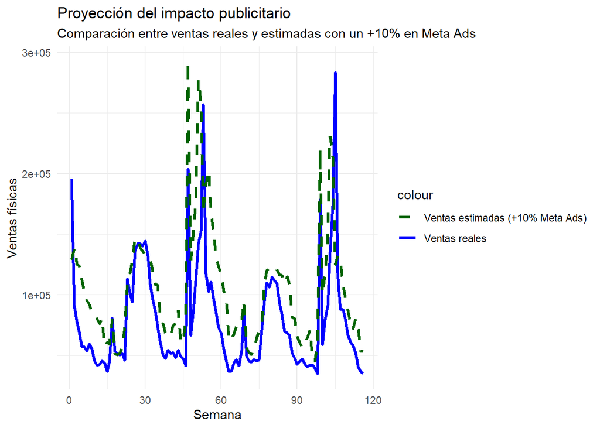

```r
# 7. Crear un data frame para graficar
df_grafico <- data.frame(
  Semana = 1:nrow(modelo_1),
  Ventas_Reales = modelo_1$ud_venta_fisica,
  Ventas_Simuladas = df_sim$ventas_simuladas
)

# 8. Graficar la comparación
library(ggplot2)

ggplot(df_grafico, aes(x = Semana)) +
  geom_line(aes(y = Ventas_Reales, color = "Ventas reales"), size = 1.2) +
  geom_line(aes(y = Ventas_Simuladas, color = "Ventas estimadas (+10% Meta Ads)"),
            size = 1.2, linetype = "dashed") +
  labs(
    title = "Proyección del impacto publicitario",
    subtitle = "Comparación entre ventas reales y estimadas con un +10% en Meta Ads",
    x = "Semana",
    y = "Ventas físicas"
  ) +
  scale_color_manual(values = c("Ventas reales" = "blue", "Ventas estimadas (+10% Meta Ads)" = "darkgreen")) +
  theme_minimal()
```

A partir del modelo estimado, se ha evaluado el impacto que tendría un incremento del 10% en la inversión publicitaria gestionada a través de Meta Ads. Los resultados indican que este aumento se traduciría en un incremento medio del 32,37% en las ventas físicas semanales, manteniendo constantes el resto de las variables del modelo.

En la gráfica se representa la comparación entre las ventas reales (línea azul) y las ventas estimadas bajo el escenario de mayor inversión (línea verde discontinua). Puede observarse que el aumento de ventas proyectado es generalizado, aunque especialmente visible en los picos de actividad comercial, como las campañas de fin de año.

Este análisis pone de manifiesto el potencial multiplicador de la inversión publicitaria digital cuando se evalúa con herramientas econométricas como el Marketing Mix Modeling. Aunque se trata de una estimación basada en un escenario hipotético, los resultados ofrecen una base sólida para orientar decisiones presupuestarias en futuras campañas.

**Evaluación del impacto de una disminuución del 10% en la inversión publicitaria**

```r
# 1. Crear una copia del dataset original
df_sim_neg <- modelo_1

# 2. Reducir en un 10% la variable sat_adstock_impresiones
df_sim_neg$sat_adstock_impresiones <- df_sim_neg$sat_adstock_impresiones * 0.90

# 3. Predecir las ventas logarítmicas con el modelo ajustado
df_sim_neg$log_ventas_simuladas <- predict(modelo_mmm_1, newdata = df_sim_neg)

# 4. Transformar las predicciones a escala original
df_sim_neg$ventas_simuladas <- exp(df_sim_neg$log_ventas_simuladas)

# 5. Calcular el cambio porcentual medio en ventas
ventas_simuladas_media_neg <- mean(df_sim_neg$ventas_simuladas)
decremento_pct <- ((ventas_simuladas_media_neg - ventas_reales_media) / ventas_reales_media) * 100

# 6. Mostrar resultado
cat(sprintf(
  "Con una reducción del 10%% en la inversión publicitaria, las ventas físicas semanales disminuirían en promedio un %.2f%%.\n",
  abs(decremento_pct)
))
```

```
## Con una reducción del 10% en la inversión publicitaria, las ventas físicas semanales disminuirían en promedio un 29.96%.
```

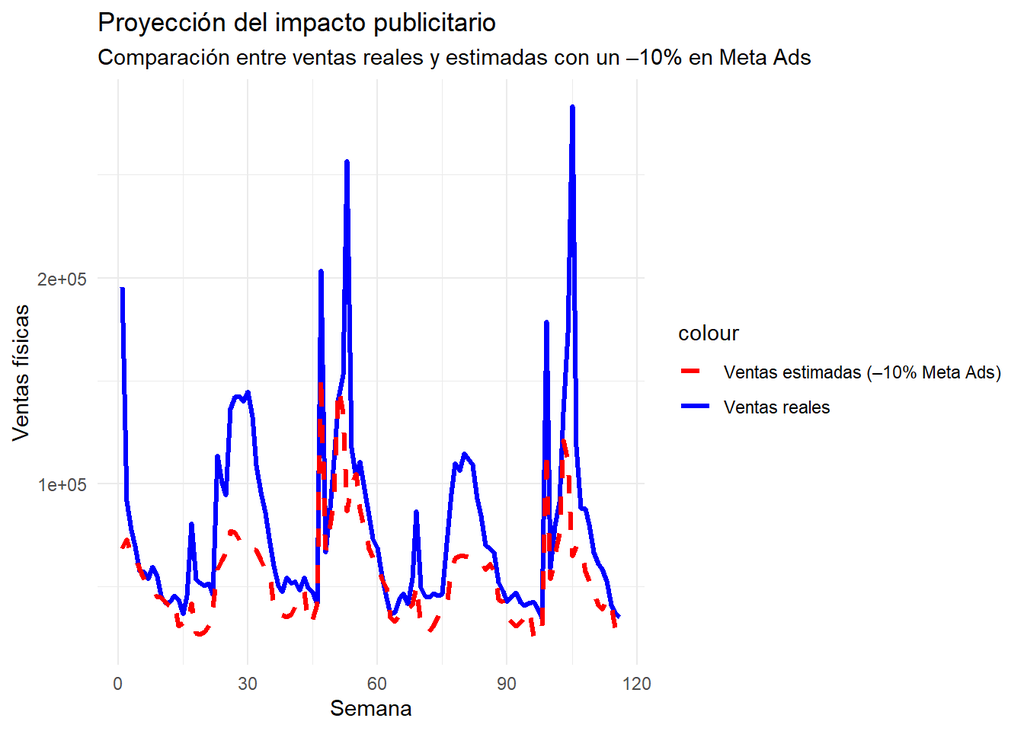

```r
# 7. Crear data frame para graficar
df_grafico_neg <- data.frame(
  Semana = 1:nrow(modelo_1),
  Ventas_Reales = modelo_1$ud_venta_fisica,
  Ventas_Simuladas = df_sim_neg$ventas_simuladas
)

# 8. Gráfico
ggplot(df_grafico_neg, aes(x = Semana)) +
  geom_line(aes(y = Ventas_Reales, color = "Ventas reales"), size = 1.2) +
  geom_line(aes(y = Ventas_Simuladas, color = "Ventas estimadas (–10% Meta Ads)"),
            size = 1.2, linetype = "dashed") +
  labs(
    title = "Proyección del impacto publicitario",
    subtitle = "Comparación entre ventas reales y estimadas con un –10% en Meta Ads",
    x = "Semana",
    y = "Ventas físicas"
  ) +
  scale_color_manual(values = c("Ventas reales" = "blue", "Ventas estimadas (–10% Meta Ads)" = "red")) +
  theme_minimal()
```

A partir del modelo estimado, se ha evaluado el efecto que tendría una reducción del 10% en la inversión publicitaria gestionada a través de Meta Ads. Los resultados obtenidos indican que esta disminución provocaría una caída media del 29,96% en las ventas físicas semanales, manteniéndose constantes el resto de factores del modelo.

En la visualización se compara la trayectoria de las ventas reales (línea azul) con la estimación del modelo bajo el escenario de menor inversión (línea roja discontinua). Se observa una caída generalizada en las ventas estimadas a lo largo del periodo, con un efecto particularmente visible en los picos de demanda, lo que refuerza el papel relevante de la publicidad digital como palanca para amplificar campañas clave.

Este ejercicio pone de manifiesto el riesgo de reducir de forma agresiva el presupuesto publicitario, especialmente si no se acompaña de otras acciones compensatorias. Los resultados sugieren que una disminución del gasto en Meta Ads podría tener un impacto notablemente negativo en los resultados comerciales, según las estimaciones del modelo.

# 8. Gráfico Comparativo: VENTAS REALES vs VENTAS ESTIMADAS

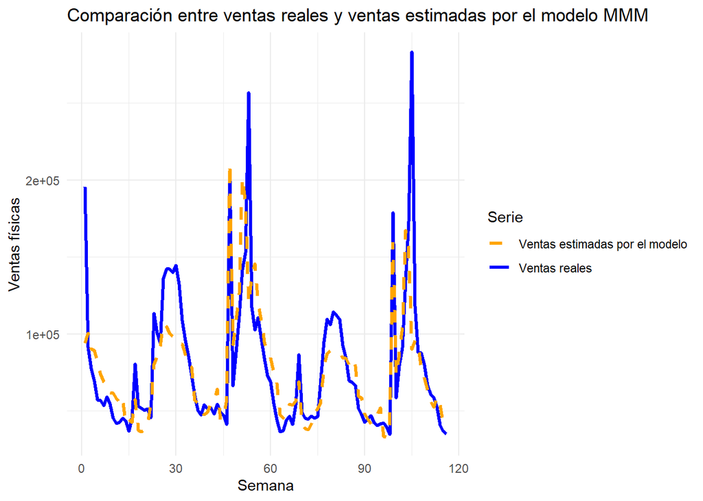

```r
# 1. Predecir las ventas (en log) con el modelo estimado
modelo_1$log_ventas_estimadas <- predict(modelo_mmm_1, newdata = modelo_1)

# 2. Transformar a escala original
modelo_1$ventas_estimadas <- exp(modelo_1$log_ventas_estimadas)

# 3. Crear el gráfico comparativo
library(ggplot2)

ggplot(modelo_1, aes(x = 1:nrow(modelo_1))) +
  geom_line(aes(y = ud_venta_fisica, color = "Ventas reales"), size = 1.2) +
  geom_line(aes(y = ventas_estimadas, color = "Ventas estimadas por el modelo"),
            linetype = "dashed", size = 1.2) +
  labs(
    title = "Comparación entre ventas reales y ventas estimadas por el modelo MMM",
    x = "Semana",
    y = "Ventas físicas",
    color = "Serie"
  ) +
  scale_color_manual(values = c("Ventas reales" = "blue", "Ventas estimadas por el modelo" = "orange")) +
  theme_minimal()
```

El modelo reproduce con buena precisión tanto la forma general de la serie como las principales fluctuaciones, lo que indica que logra captar adecuadamente las dinámicas de ventas físicas en función de las variables explicativas utilizadas. Aunque existen pequeñas desviaciones puntuales, la coherencia entre ambas líneas refuerza la validez del modelo como herramienta para estimar el impacto de la inversión publicitaria y otros factores comerciales.

Este ajuste visual complementa el buen nivel de𝑅^2 ajustado obtenido (0.7072) y confirma que el modelo tiene capacidad predictiva sólida, al menos dentro del rango de datos utilizado para su estimación.